# Local Poisson regression

Adrià Casanova, Silvia Ferrer, Matteo Mazzini

2024-12-10

```r
library(sm)
library(latex2exp)
```

# 1. Bandwidth choice for the local Poisson regression

In this analysis, we implemented a method for bandwidth selection in local Poisson regression using leave-one-out cross-validation (LOO-CV). This was done by modifying the formulas provided:

1. The **LOO-CV log-likelihood** for a given bandwidth $h$ is computed as:
   $$\ell_{CV}(h) = \frac{1}{n} \sum_{i=1}^n
   \log\left(\widehat{\text{Pr}}_h^{(-i)}(le.fm.r = y_i | Life.expec =
   x_i)\right),$$
   where $\widehat{\text{Pr}}_h^{(-i)}(le.fm.r = y_i | Life.expec = x_i)$ is the estimated probability excluding the $i$-th observation.
2. For Poisson regression:
   $$\widehat{\text{Pr}}_h^{(-i)}(le.fm.r = y_i | Life.expec = x_i) =
   e^{-\lambda_i} \frac{\lambda_i^{y_i}}{y_i!},$$
   where $\lambda_i = \mathbb{E}[le.fm.r | Life.expec = x_i]$, estimated using a locally weighted regression model.
3. The optimal bandwidth $h$ is the one that maximizes $\ell_{CV}(h)$.
- **`loglik.CV` Function**: Calculates the LOO log-likelihood for a given bandwidth $h$. For each observation:
  1. Leave out the $i$-th data point.
  2. Fit a Poisson regression using kernel weights based on the bandwidth $h$.
  3. Predict the mean parameter $\lambda_i$ for the left-out observation and compute the log-likelihood. Returns the negative average log-likelihood. This is used as a measure of model fit for the chosen bandwidth $h$.
- **`h.cv.sm.poisson` Function**: Evaluates the log-likelihood for a sequence of bandwidth values and selects the one that maximizes the LOO log-likelihood. Returns a list containing:
  1. $h$: Sequence of bandwidths considered.
  2. $cv.h$: Corresponding LOO log-likelihood values for each bandwidth.
  3. $h.cv$: Optimal bandwidth minimizing the LOO log-likelihood.

```r
h.cv.sm.poisson <- function(x, y, l.h = 10) {
  hh <- h.select(x, y, method = "cv")
  rg.h <- range(hh) * c(1 / 1.1, 1.5)

  gr.h <- exp(seq(log(rg.h[1]), log(rg.h[2]), length.out = l.h))

  cv.h <- sapply(gr.h, function(h) loglik.CV(x, y, h))

  return(list(
    h = gr.h,
    cv.h = cv.h,
    h.cv = gr.h[which.min(cv.h)]
  ))
}


loglik.CV <- function(x,y,h){
  n <- length(x)
  probs <- sapply(1:n,
      function(i,x,y,h){
         lambda<-sm.poisson(x=x[-i],y=y[-i],h=h,eval.points=x[i],
                            display="none")$estimate
         return(dpois(y[i],lambda))
      },   x,y,h)


  return(-sum( log(probs) )/n)
}
```

# 2. Local Poisson regression for Country Development Data

First we read the data and define ‘le.fm.r’ as the rounded value of ‘le.fm’. The ‘le.fm’ column represents the difference between female and male life expectancy. The ‘Life.expec’ column represents the overall life expectancy.

```r
data <- read.csv(file="HDI.2017.subset.csv", sep = ";", dec = ",")
data$le.fm.r <- round(data$le.fm)
attach(data)
```

We can first plot ‘Life.expec’ against ‘le.fm.r’ to see how they are distributed.

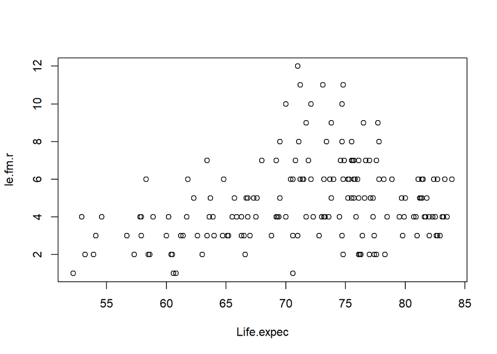

```r
plot(le.fm.r ~ Life.expec)
```

The plot suggests that countries with higher ‘le.fm.r’ values, 7 years and above, tend to be grouped within a more limited life expectancy range of approximately 70–80 years. Lower ‘le.fm.r’ values are associated with both lower and higher life expectancies, indicating more variability.

Then, we compute the optimal bandwidth $h$ using **`h.cv.sm.poisson`** function.

```r
opt_h <- h.cv.sm.poisson(Life.expec, le.fm.r)

cat(opt_h$h.cv)
```

```
## 2.686371
```

We can see how the rest values of $h$ perform:

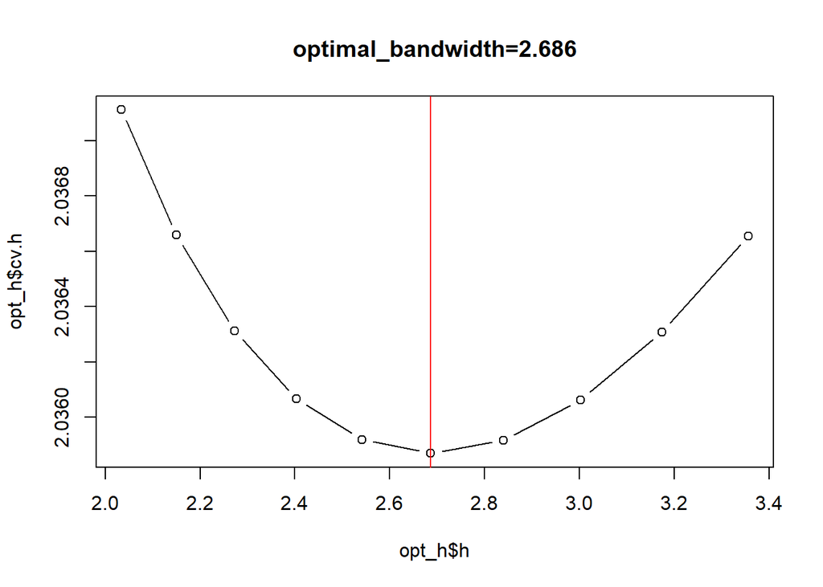

```r
plot(opt_h$h, opt_h$cv.h, type="b", main=paste0("optimal_bandwidth=", round(opt_h$h.cv, 3)))
abline(v=opt_h$h.cv, col="red")
```

Then, we fit a local Poisson regression model using the optimal bandwidth $h$.

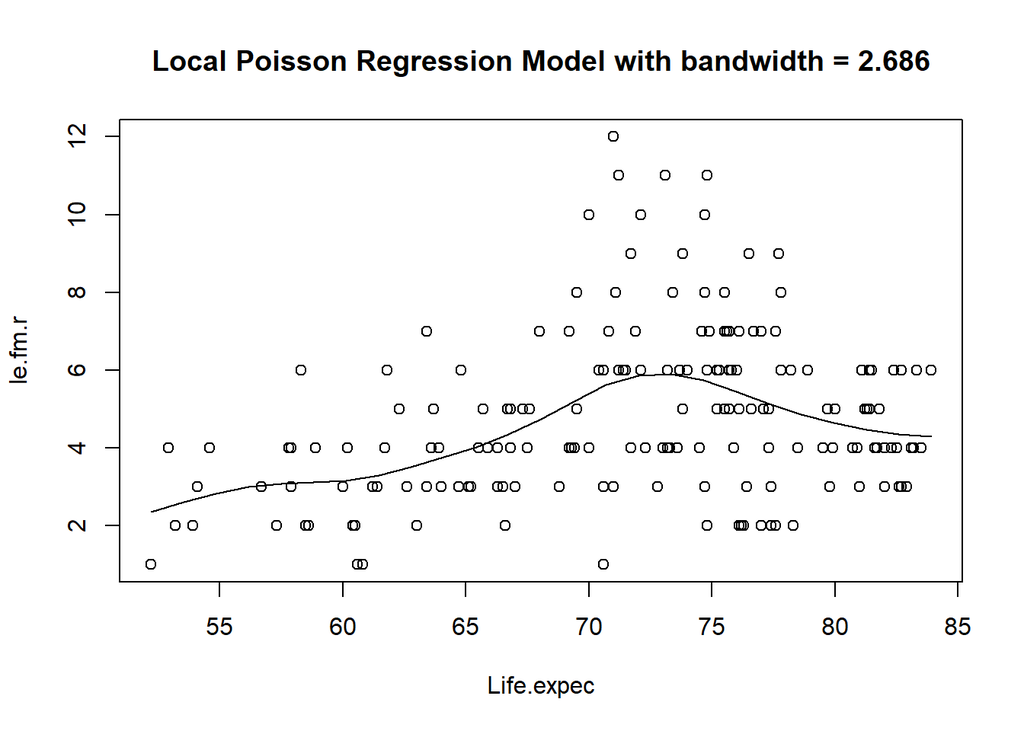

```r
sm_model <- sm.poisson(Life.expec, le.fm.r, h = opt_h$h.cv, col=1)
title(main=paste("Local Poisson Regression Model with bandwidth = ", round(opt_h$h.cv,3), sep=""))
```

Looking at the plot of the fitted poisson regression model we can observe different things:

- There is significant dispersion in the ‘le.fm.r’ values for a given ‘Life.expec’, which suggests that other factors besides ‘Life.expec’ influence ‘le.fm.r’.
- The variability in the data suggests that the model does not capture the relationship very strongly. While the Poisson model identifies a general trend, it does not account for the substantial spread of data points around the fitted line.

We should consider to add covariates of the data provided to capture more of the variability in ‘le.fm.r’.